# *LAB 1*

### Μέλη ομάδας

```
1.Κωνσταντίνος Κανελλής          - <kkanellis@uth.gr> (ΑΕΜ: 1763)

2.Ελευθέριος Παναγιώτης Λούκας   - <eloukas@uth.gr>  (ΑΕΜ: 2029)

3.Κλάιντι Μποντούρρι             - <kbontourri@uth.gr> (ΑΕΜ: 2020)
```

```r
# read .csv
college = read.csv("College.csv")

# get college names
rownames(college) = college[,1]

# eliminate the first column
college = college[,-1]
```

Με την εντολή summary μπορούμε να πάρουμε γρήγορα κάποια στατιστικά όπως το max, min, mean για να έχουμε μια γενική εικόνα των δεδομένων μας. Ένα παράδειγμα τέτοιας χρήσης θα ήταν αν κάποιος ενδιαφέρεται να μάθει πόσες χρηματικές μονάδες είναι το μέσο κόστος Room and Board για ένα φοιτητή.

```r
# produce a numerical summary of the variables in the data set
summary(college)
```

```
 Private        Apps           Accept          Enroll       Top10perc
 No :212   Min.   :   81   Min.   :   72   Min.   :  35   Min.   : 1.00
 Yes:565   1st Qu.:  776   1st Qu.:  604   1st Qu.: 242   1st Qu.:15.00
           Median : 1558   Median : 1110   Median : 434   Median :23.00
           Mean   : 3002   Mean   : 2019   Mean   : 780   Mean   :27.56
           3rd Qu.: 3624   3rd Qu.: 2424   3rd Qu.: 902   3rd Qu.:35.00
           Max.   :48094   Max.   :26330   Max.   :6392   Max.   :96.00
   Top25perc      F.Undergrad     P.Undergrad         Outstate
 Min.   :  9.0   Min.   :  139   Min.   :    1.0   Min.   : 2340
 1st Qu.: 41.0   1st Qu.:  992   1st Qu.:   95.0   1st Qu.: 7320
 Median : 54.0   Median : 1707   Median :  353.0   Median : 9990
 Mean   : 55.8   Mean   : 3700   Mean   :  855.3   Mean   :10441
 3rd Qu.: 69.0   3rd Qu.: 4005   3rd Qu.:  967.0   3rd Qu.:12925
 Max.   :100.0   Max.   :31643   Max.   :21836.0   Max.   :21700
   Room.Board       Books           Personal         PhD
 Min.   :1780   Min.   :  96.0   Min.   : 250   Min.   :  8.00
 1st Qu.:3597   1st Qu.: 470.0   1st Qu.: 850   1st Qu.: 62.00
 Median :4200   Median : 500.0   Median :1200   Median : 75.00
 Mean   :4358   Mean   : 549.4   Mean   :1341   Mean   : 72.66
 3rd Qu.:5050   3rd Qu.: 600.0   3rd Qu.:1700   3rd Qu.: 85.00
 Max.   :8124   Max.   :2340.0   Max.   :6800   Max.   :103.00
    Terminal       S.F.Ratio      perc.alumni        Expend
 Min.   : 24.0   Min.   : 2.50   Min.   : 0.00   Min.   : 3186
 1st Qu.: 71.0   1st Qu.:11.50   1st Qu.:13.00   1st Qu.: 6751
 Median : 82.0   Median :13.60   Median :21.00   Median : 8377
 Mean   : 79.7   Mean   :14.09   Mean   :22.74   Mean   : 9660
 3rd Qu.: 92.0   3rd Qu.:16.50   3rd Qu.:31.00   3rd Qu.:10830
 Max.   :100.0   Max.   :39.80   Max.   :64.00   Max.   :56233
   Grad.Rate
 Min.   : 10.00
 1st Qu.: 53.00
 Median : 65.00
 Mean   : 65.46
 3rd Qu.: 78.00
 Max.   :118.00
```

Mε το scatterplot προσπαθούμε να δούμε πως συμπεριφέρονται “ζευγάρια” δεδομένων όπως για παράδειγμα μεταξύ Apps και Accept students. Στην παρακάτω είναι το scatterplot απο 10 πρώτες μεταβλητές των δεδομένων.

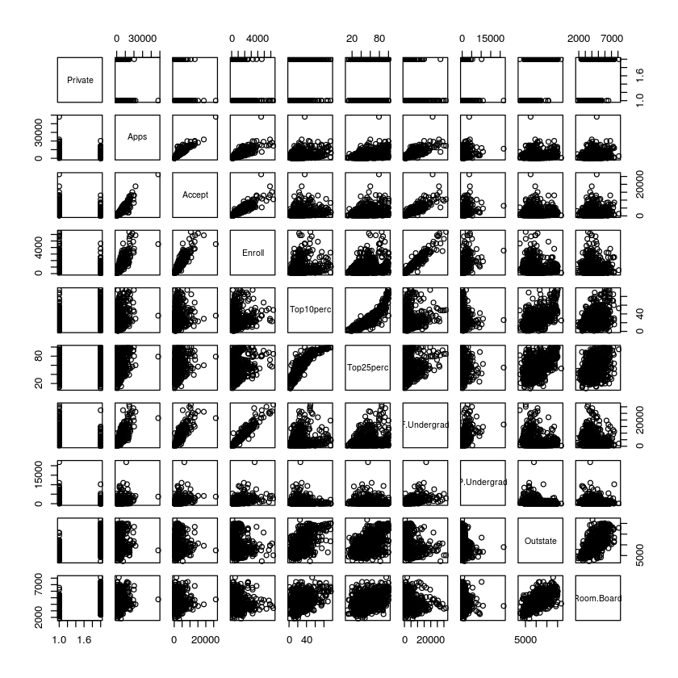

```r
# A scatterplot matrix of the first ten columns or variables of the data
# A scatterplot graph gives correlation between data!
pairs(college[,1:10])
```

Με το boxplot μπορούμε να συγκρίνουμε 2 μεταβλητές όπως για παράδειγμα το Outstate με το Private. Δηλαδή μπορούμε να δούμε τι γίνεται με τα εξωτερικά δίδακτρα αν ένα πανεπιστήμιο είναι ιδιωτικό ή όχι.

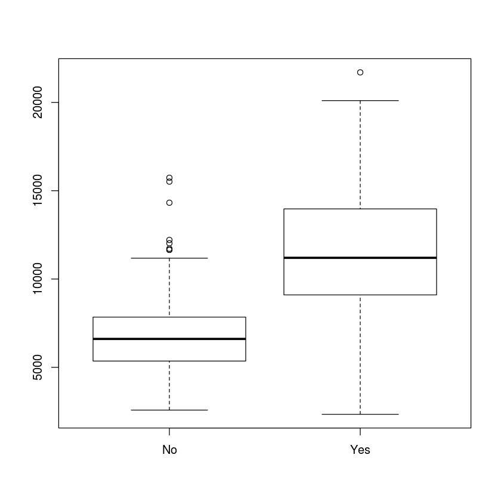

```r
# side-by-side boxplots of Outstate versus Private
boxplot(college$Outstate~college$Private)
```

Εδώ παρατηρούμε ότι στα μη ιδιωτικά πανεπιστήμια τα εξωτερικά έξοδα είναι εμφανώς λιγότερα από αυτά των ιδιωτικών (με μικρές εξαιρέσεις). Επίσης με το boxplot μπορούμε να δούμε ποιό είναι συμμετρικό. (Αν η bold γραμμή είναι στο κέντρο του ορθογωνίου ή όχι.)

Στην συνέχεια ζητήθηκε να συγκρίνουμε τo Outstate με το αν ένα πανεπίστημιο είναι Elite ή όχι. ( Elite χαρακτηρίζεται όποιο πανεπιστήμιο έχει > 50% των Top10perc ) Με το summary μπορούμε να δούμε πόσα πανεπιστήμια είναι Elite και με το boxplot κάποια χαρακτηριστικά όπως εξηγήθηκε παραπάνω.

```r
# create a qualitative variable!
Elite = rep("No", nrow(college))
Elite[college$Top10perc > 50] = "Yes"
Elite = as.factor(Elite)
college = data.frame(college,Elite)

# how many elite univer-sities there are.
summary(college$Elite)
```

**No**

699

**Yes**

78

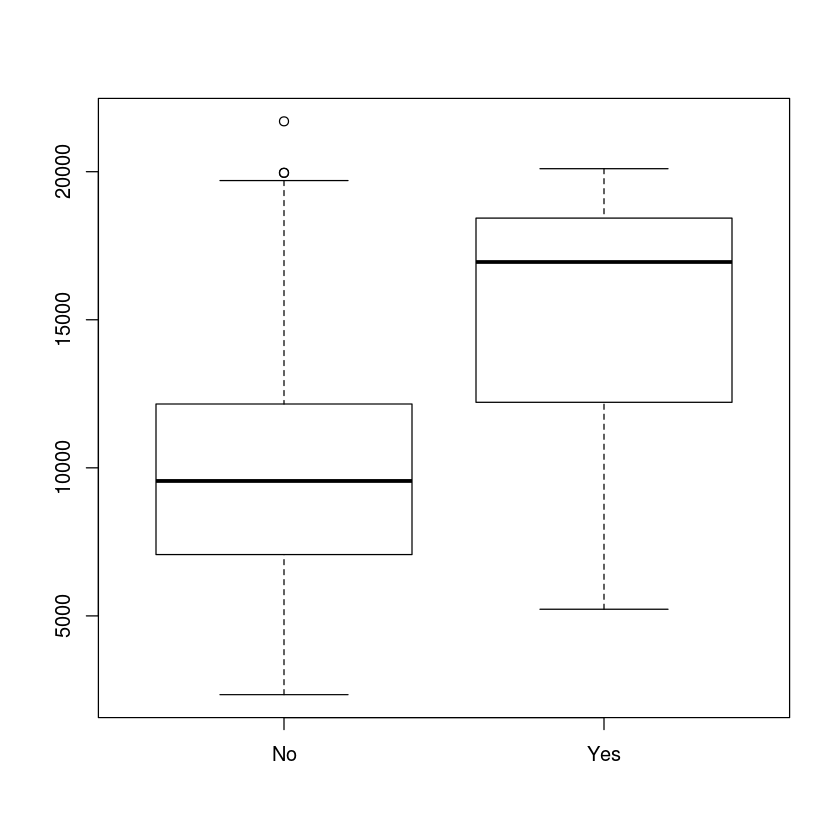

```r
boxplot(college$Outstate~college$Elite)
```

Και εδώ είναι εμφανές πόσα περισσότερα είναι τα εξωτερικά δίδακτρα σε ένα Elite πανεπιστήμιο.

Τέλος, με τα histograms μπορούμε να πάρουμε μια εικόνα για το πώς κατανέμονται οι διάφορες τιμές των μεταβλητών. Για παράδειγμα, παρακάτω υπάρχει ιστόγραμμα για τα έξοδα του φοιτητή (Room.Board, Books, Personal, Outstate).

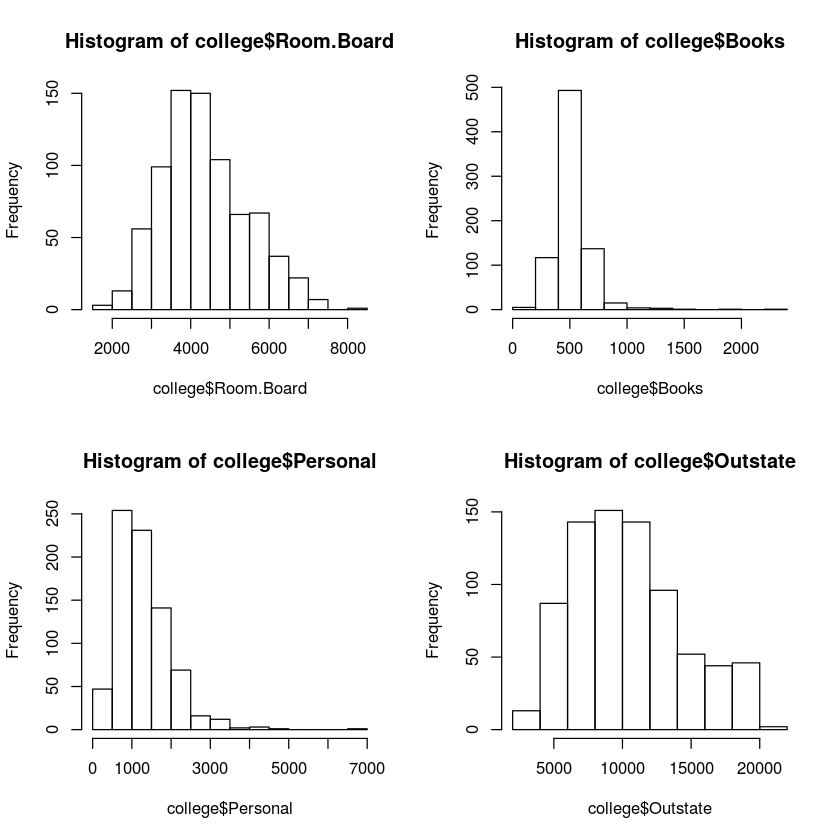

```r
# some histograms
par(mfrow = c(2,2))
hist(college$Room.Board)
hist(college$Books)
hist(college$Personal)
hist(college$Outstate)
```

Github repository: https://github.com/eloukas/PSEs-and-Data-Science

Μπορείτε να επικοινωνήσετε μαζί μας αν θέλετε να επιβεβαιώσετε τον κώδικα.

(το repo είναι private προσωρινά)

Κωνσταντίνος Κανελλής - kkanellis@uth.gr (ΑΕΜ: 1763)

Ελευθέριος Παναγιώτης Λούκας - eloukas@uth.gr (ΑΕΜ: 2029)

Κλάιντι Μποντούρρι - kbontourri@uth.gr (ΑΕΜ: 2020)